```python
import numpy as np
import pandas as pd
import seaborn as sb
from matplotlib import pyplot as plt
from sklearn.linear_model import LinearRegression
from sklearn.utils import resample
import time
from sklearn.preprocessing import StandardScaler
from sklearn.linear_model import SGDRegressor
from sklearn.linear_model import SGDClassifier
from sklearn.linear_model import LogisticRegression
from sklearn.metrics import mean_squared_error as mse
from sklearn.metrics import log_loss
from sklearn.metrics import accuracy_score as accuracy
```

```python
dataset = pd.read_csv("possum.csv")
dataset.shape
```

```
(104, 14)
```

Удаляем пропуски

```python
print(dataset.isna().values.sum())
```

```
3
```

```python
dataset = dataset.dropna()
```

Датасет состоит из девяти морфометрических измерений каждого из 104 горных опоссумов, пойманных в ловушку в семи местах от Южной Виктории до центрального Квинсленда. site - место, в котором поймали опоссума

Pop - популяция: Vic - Victoria, other - New South Wales or Queensland

sex - пол

age - возраст

hdlngth - длина головы в мм

skullw - ширина черепа в мм

totlngth - полная длина в см

taill - длина хвоста

footlgth - длина лапы

earconch - длина ушной раковины

eye - длина правого глаза

chest - обхват груди в см

belly - обхват живота в см

```python
dataset.head()
```

|  | case | site | Pop | sex | age | hdlngth | skullw | totlngth | taill | footlgth | earconch | eye | chest | belly |
| --- | --- | --- | --- | --- | --- | --- | --- | --- | --- | --- | --- | --- | --- | --- |
| 0 | 1 | 1 | Vic | m | 8.0 | 94.1 | 60.4 | 89.0 | 36.0 | 74.5 | 54.5 | 15.2 | 28.0 | 36.0 |
| 1 | 2 | 1 | Vic | f | 6.0 | 92.5 | 57.6 | 91.5 | 36.5 | 72.5 | 51.2 | 16.0 | 28.5 | 33.0 |
| 2 | 3 | 1 | Vic | f | 6.0 | 94.0 | 60.0 | 95.5 | 39.0 | 75.4 | 51.9 | 15.5 | 30.0 | 34.0 |
| 3 | 4 | 1 | Vic | f | 6.0 | 93.2 | 57.1 | 92.0 | 38.0 | 76.1 | 52.2 | 15.2 | 28.0 | 34.0 |
| 4 | 5 | 1 | Vic | f | 2.0 | 91.5 | 56.3 | 85.5 | 36.0 | 71.0 | 53.2 | 15.1 | 28.5 | 33.0 |

Задача регрессии состоит в определении возраста по количественным признакам.

```python
data = dataset.drop(["case","site","sex"], axis=1)
data.head()
```

|  | Pop | age | hdlngth | skullw | totlngth | taill | footlgth | earconch | eye | chest | belly |
| --- | --- | --- | --- | --- | --- | --- | --- | --- | --- | --- | --- |
| 0 | Vic | 8.0 | 94.1 | 60.4 | 89.0 | 36.0 | 74.5 | 54.5 | 15.2 | 28.0 | 36.0 |
| 1 | Vic | 6.0 | 92.5 | 57.6 | 91.5 | 36.5 | 72.5 | 51.2 | 16.0 | 28.5 | 33.0 |
| 2 | Vic | 6.0 | 94.0 | 60.0 | 95.5 | 39.0 | 75.4 | 51.9 | 15.5 | 30.0 | 34.0 |
| 3 | Vic | 6.0 | 93.2 | 57.1 | 92.0 | 38.0 | 76.1 | 52.2 | 15.2 | 28.0 | 34.0 |
| 4 | Vic | 2.0 | 91.5 | 56.3 | 85.5 | 36.0 | 71.0 | 53.2 | 15.1 | 28.5 | 33.0 |

pairplot, видна неоднородность.

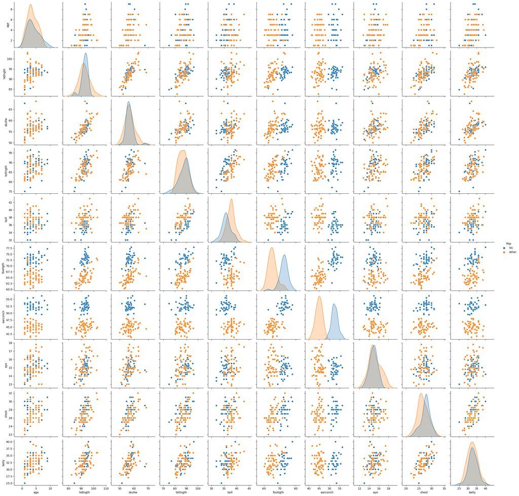

```python
sb.pairplot(data, hue="Pop")
```

Выделяем X и y для линейной регрессии.

```python
X = np.array(data.iloc[:,2:11])
y = np.array(data.iloc[:,1]).reshape(-1,1)
```

Стандартизуем признаки и добавляем столбец из единиц. (Константа для общности, после центрирования ее можно и не вычислять. Далее будем работать со стандартизованными данными, так как без стандартизации хуже сходимость: нужен маленький шаг и больше итераций)

```python
scaler_X = StandardScaler().fit(X)
X_s = scaler_X.transform(X) # Стандартизируем X
scaler_y = StandardScaler().fit(y)
y_s = scaler_y.transform(y) # Стандартизируем y
X_s_conc = np.concatenate((X_s,np.ones((X.shape[0],1))), axis=1) # Добавляем столбец из единиц
```

Попытка повторить реализацию SGDRegressor из sklearn: пробегаем по всем данным в рамках эпохи, обновление коэффициентов после каждого индивида, перемешиваем данные после каждой эпохи. betta0 - начальные коэффициенты, alpha - шаг, eps - из условия остановки (норма разности коэффициентов), max_epoch - максимальное количество эпох. Все функции возвращают массив из коэффициентов после каждого обновления.

```python
def Linear_regr_SGD_1batch(X, y, betta0, alpha, eps, max_epoch):
    N = y.shape[0]
    num_arr = np.arange(N)
    temp = alpha*X.T # Сразу вычисляем X.T * alpha, чтобы не считать повторно
    bettas = [betta0] # Начальные коэффициенты
    for _ in range(max_epoch): # Цикл по эпохам
        np.random.shuffle(num_arr) # Перемешиваем данные
        for i in num_arr: # Цикл по данным
            bettas.append(bettas[-1]-temp[:,i:i+1]*(np.dot(X[i,],bettas[-1])-y[i])) # Добавляем обновленные коэффициенты
            if (np.linalg.norm(bettas[-1]-bettas[-2])<eps): # Условие остановки
                break
    return np.array(bettas)
```

Тот же SGD, но без эпох - каждая итерация обновляет коэффициенты по случайной подвыборке размера subsample_size. max_iter - максимальное количество итераций.

```python
def Linear_regr_SGD(X, y, betta0, alpha, eps, subsample_size, max_iter):
    N = y.shape[0]
    num_arr = np.arange(N)
    bettas = [betta0]
    for _ in range(max_iter): # Цикл по итерациям
        numbers = resample(num_arr, replace=False, n_samples=subsample_size) # Случайная подвыборка
        bettas.append(bettas[-1]-alpha*X[numbers,].T.dot(np.dot(X[numbers,],bettas[-1])-y[numbers]))
        if (np.linalg.norm(bettas[-1]-bettas[-2])<eps):
            break
    return np.array(bettas)
```

Adagrad с обновлением по случайной подвыборке.

```python
def Linear_regr_Adagrad(X, y, betta0, alpha, eps, subsample_size, max_iter):
    p = X.shape[1]
    N = y.shape[0]
    m = subsample_size # Размер подвыборки
    num_arr = np.arange(N)
    bettas = [betta0]
    W = np.zeros((p,1)) # W_0
    for _ in range(max_iter): # Цикл по итерациям
        numbers = resample(num_arr, replace=False, n_samples=m) # Случайная подвыборка
        grad = X[numbers,].T.dot(np.dot(X[numbers,],bettas[-1])-y[numbers]) # Градиент
        W = W+grad**(2) # Вектор W
        bettas.append(bettas[-1]-np.sqrt(1/(W+10**(-8)))*alpha*grad) # Добавляем коэффициенты
        if (np.linalg.norm(bettas[-1]-bettas[-2])<eps): # Условие остановки
            break
    return np.array(bettas)
```

RMSProp, экспоненциальное сглаживание с коэффициентом 0.99. ($W_{i+1}=0.99\cdot{W_{i}}+0.01\cdot{grad_i^2})$

```python
def Linear_regr_RMSProp(X, y, betta0, alpha, eps, subsample_size, max_iter):
    p = X.shape[1]
    N = y.shape[0]
    m = subsample_size
    num_arr = np.arange(N)
    bettas = [betta0]
    W = np.zeros((p,1))
    for _ in range(max_iter):
        numbers = resample(num_arr, replace=False, n_samples=m)
        grad = X[numbers,].T.dot(np.dot(X[numbers,],bettas[-1])-y[numbers])
        W = 0.99*W+0.01*grad**(2) # Экспоненциальное сглаживание W
        bettas.append(bettas[-1]-np.sqrt(1/(W+10**(-8)))*alpha*grad)
        if (np.linalg.norm(bettas[-1]-bettas[-2])<eps):
            break
    return np.array(bettas)
```

Квадратичная функция риска.

```python
def cost_mse(x,y):
    return np.sum((x-y)**2)/x.shape[0]
```

Начальные коэффициенты. (далее везде будут выбраны нулевыми)

```python
b0 = np.zeros((X_s_conc.shape[1],1))
```

Вычислим коэффициенты с помощью LinearRegression из sklearn.

```python
model = LinearRegression().fit(X_s,y_s)
model_coef = np.append(model.coef_, model.intercept_).reshape(-1,1)
print("Коэффициенты:\n", model_coef)
print("MSE:\n", cost_mse(X_s_conc.dot(model_coef), y_s))
```

```
Коэффициенты:
 [[ 8.91214865e-02]
 [ 3.44508006e-02]
 [ 4.92803349e-02]
 [-3.26229551e-04]
 [-2.51151895e-01]
 [ 2.08052350e-01]
 [ 1.39504985e-01]
 [ 1.59542255e-01]
 [ 2.04679158e-01]
 [ 7.20250481e-16]]
MSE:
 0.805877997124848
```

То же самое, если вычислять по формуле.

```python
true_bettas = np.linalg.inv(X_s_conc.T.dot(X_s_conc)).dot(X_s_conc.T.dot(y_s))
print("Коэффициенты:\n", true_bettas)
print("MSE:\n", cost_mse(X_s_conc.dot(true_bettas), y_s))
```

```
Коэффициенты:
 [[ 8.91214865e-02]
 [ 3.44508006e-02]
 [ 4.92803349e-02]
 [-3.26229551e-04]
 [-2.51151895e-01]
 [ 2.08052350e-01]
 [ 1.39504985e-01]
 [ 1.59542255e-01]
 [ 2.04679158e-01]
 [ 7.45384203e-16]]
MSE:
 0.8058779971248483
```

SGDRegressor из sklearn, количество эпох = 1000, шаг равен 0.001.

```python
regr = SGDRegressor(max_iter=1000, tol=None, penalty=None, learning_rate="constant", eta0=0.001) # Модель
regr.fit(X_s,y_s.T[0], coef_init=np.zeros((9,1)),intercept_init=np.zeros(1)) # Обучение
regr_coef = np.append(regr.coef_, regr.intercept_).reshape(-1,1)
print("Коэффициенты:\n", regr_coef)
print("MSE:\n", cost_mse(X_s_conc.dot(regr_coef), y_s))
```

```
Коэффициенты:
 [[ 0.09057687]
 [ 0.03556365]
 [ 0.05050226]
 [-0.00120046]
 [-0.25124198]
 [ 0.20987183]
 [ 0.13965634]
 [ 0.16190416]
 [ 0.20687099]
 [-0.00202055]]
MSE:
 0.8059337574029184
```

Реализация SGD по эпохам с такими же параметрами.

```python
coef_batch = Linear_regr_SGD_1batch(X_s_conc, y_s, betta0=b0, alpha=0.001, eps=10**(-8), max_epoch=1000)
print("Коэффициенты:\n",coef_batch[-1])
print("MSE:\n", cost_mse(X_s_conc.dot(coef_batch[-1]), y_s))
```

```
Коэффициенты:
 [[ 0.08921597]
 [ 0.03397988]
 [ 0.05009362]
 [-0.00028769]
 [-0.24969439]
 [ 0.2107112 ]
 [ 0.13968439]
 [ 0.16033721]
 [ 0.20533117]
 [-0.00040088]]
MSE:
 0.8059009469576409
```

Графики функции риска по эпохам почти совпадают.

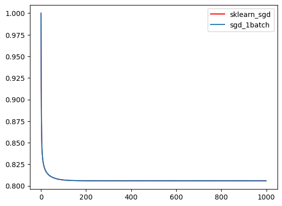

```python
cost_sklearn = [cost_mse(X_s_conc.dot(np.zeros((10,1))),y_s)]
cost_batch = []

# Модель sklearn не возвращает историю функции риска.
# Можно возвращать коэффициенты после каждой итерации с параметром warm_start=True
regr_temp = SGDRegressor(max_iter=1, tol=None, penalty=None, learning_rate="constant", eta0=0.001, warm_start=True) # Модель
regr_temp.fit(X_s,y_s.T[0], coef_init=np.zeros((9,1)),intercept_init=np.zeros(1)) # Обучение (1 итерация), beta_0=[0]_p
regr_temp_coef = np.append(regr_temp.coef_, regr_temp.intercept_).reshape(-1,1)
cost_sklearn.append(cost_mse(X_s_conc.dot(regr_temp_coef),y_s)) # Добавляем значение функции риска

for i in range(regr.n_iter_):
    regr_temp.fit(X_s,y_s.T[0]) # Обучение (1 итерация)
    regr_temp_coef = np.append(regr_temp.coef_, regr_temp.intercept_).reshape(-1,1)
    cost_sklearn.append(cost_mse(X_s_conc.dot(regr_temp_coef),y_s))
    cost_batch.append(cost_mse(X_s_conc.dot(coef_batch[101*i]),y_s)) # Добавляем значение функции риска

plt.plot(cost_sklearn[:-2],color="r", label="sklearn_sgd")
plt.plot(cost_batch, label="sgd_1batch")
plt.legend()
```

SGD по случайной подвыборке. 10000 итераций, подвыборка размера 10, шаг равен 0.001.

```python
coef_sgd = Linear_regr_SGD(X_s_conc, y_s, betta0=b0, alpha=0.001, eps=10**(-8), subsample_size=10, max_iter=10000)
print("Коэффициенты:\n",coef_sgd[-1])
print("MSE:\n", cost_mse(X_s_conc.dot(coef_sgd[-1]), y_s))
```

```
Коэффициенты:
 [[ 0.08872664]
 [ 0.02293633]
 [ 0.05346658]
 [-0.00971568]
 [-0.23280782]
 [ 0.20858079]
 [ 0.09461566]
 [ 0.16107177]
 [ 0.233388  ]
 [ 0.01878123]]
MSE:
 0.8094074130547956
```

Adagrad.

```python
coef_adagrad = Linear_regr_Adagrad(X_s_conc,y_s,betta0=b0,alpha=0.001,eps=10**(-8),subsample_size=10, max_iter=10000)
print("Коэффициенты:\n",coef_adagrad[-1])
print("MSE:\n", cost_mse(X_s_conc.dot(coef_adagrad[-1]), y_s))
```

```
Коэффициенты:
 [[ 0.07473645]
 [ 0.06212708]
 [ 0.0528294 ]
 [ 0.02131425]
 [ 0.00837065]
 [ 0.01973164]
 [ 0.07798916]
 [ 0.0781468 ]
 [ 0.09874714]
 [-0.00189487]]
MSE:
 0.8369944203642022
```

RMSProp.

```python
coef_rms = Linear_regr_RMSProp(X_s_conc,y_s,betta0=b0,alpha=0.001,eps=10**(-8),subsample_size=10, max_iter=10000)
print("Коэффициенты:\n",coef_rms[-1])
print("MSE:\n", cost_mse(X_s_conc.dot(coef_rms[-1]), y_s))
```

```
Коэффициенты:
 [[ 0.09327377]
 [ 0.0148997 ]
 [ 0.03540325]
 [-0.00363674]
 [-0.24093862]
 [ 0.20249775]
 [ 0.15479981]
 [ 0.17764309]
 [ 0.19129753]
 [-0.01016482]]
MSE:
 0.8065732368929492
```

Графики функции риска по итерациям. Видна особенность Adagrad, которую исправляет RMSProp - слишком быстрое уменьшение шага.

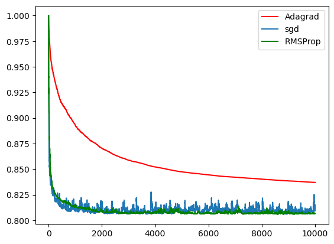

```python
cost_sgd = []
cost_adagrad = []
cost_rms = []

for i in range(coef_sgd.shape[0]):
    cost_sgd.append(cost_mse(X_s_conc.dot(coef_sgd[i]),y_s)) # Добавляем значения функции риска
    cost_adagrad.append(cost_mse(X_s_conc.dot(coef_adagrad[i]),y_s))
    cost_rms.append(cost_mse(X_s_conc.dot(coef_rms[i]),y_s))

plt.plot(cost_adagrad,color="r", label="Adagrad")
plt.plot(cost_sgd, label="sgd")
plt.plot(cost_rms,color="g", label="RMSProp")
plt.legend()
```

В рамках логистической регрессии будем определять популяцию по тем же количественным признакам.

```python
data['Pop'] = pd.factorize(data['Pop'])[0]
data.tail()
```

|  | Pop | age | hdlngth | skullw | totlngth | taill | footlgth | earconch | eye | chest | belly |
| --- | --- | --- | --- | --- | --- | --- | --- | --- | --- | --- | --- |
| 99 | 1 | 1.0 | 89.5 | 56.0 | 81.5 | 36.5 | 66.0 | 46.8 | 14.8 | 23.0 | 27.0 |
| 100 | 1 | 1.0 | 88.6 | 54.7 | 82.5 | 39.0 | 64.4 | 48.0 | 14.0 | 25.0 | 33.0 |
| 101 | 1 | 6.0 | 92.4 | 55.0 | 89.0 | 38.0 | 63.5 | 45.4 | 13.0 | 25.0 | 30.0 |
| 102 | 1 | 4.0 | 91.5 | 55.2 | 82.5 | 36.5 | 62.9 | 45.9 | 15.4 | 25.0 | 29.0 |
| 103 | 1 | 3.0 | 93.6 | 59.9 | 89.0 | 40.0 | 67.6 | 46.0 | 14.8 | 28.5 | 33.5 |

```python
y_log = np.array(data.iloc[:,0]).reshape(-1,1)
```

Сигмоида и log loss (задача минимизации log loss).

```python
def sigmoid(x):
    return 1 / (1 + np.exp(-x))
```

```python
def cost_log(pred,true):
    return -(true.T.dot(np.log(pred))+(1-true).T.dot(np.log(1-pred))).reshape(-1)[0]
```

Те же методы, но $grad = X^T(\sigma(X\beta)-y)$.

```python
def Log_regr_SGD_1batch(X, y, betta0, alpha, eps, max_epoch):
    N = y.shape[0]
    num_arr = np.arange(N)
    temp = alpha*X.T
    bettas = [betta0]
    for _ in range(max_epoch):
        np.random.shuffle(num_arr)
        for i in num_arr:
            bettas.append(bettas[-1]-temp[:,i:i+1]*(sigmoid(np.dot(X[i,],bettas[-1]))-y[i]))
            if (np.linalg.norm(bettas[-1]-bettas[-2])<eps):
                break
    return np.array(bettas)
```

```python
def Log_regr_SGD(X, y, betta0, alpha, eps, subsample_size, max_iter):
    N = y.shape[0]
    num_arr = np.arange(N)
    bettas = [betta0]
    for _ in range(max_iter):
        numbers = resample(num_arr, replace=False, n_samples=subsample_size)
        bettas.append(bettas[-1]-alpha*X[numbers,].T.dot(sigmoid(np.dot(X[numbers,],bettas[-1]))-y[numbers]))
        if (np.linalg.norm(bettas[-1]-bettas[-2])<eps):
            break
    return np.array(bettas)
```

```python
def Log_regr_Adagrad(X, y, betta0, alpha, eps, subsample_size, max_iter):
    p = X.shape[1]
    N = y.shape[0]
    m = subsample_size
    num_arr = np.arange(N)
    bettas = [betta0]
    W = np.zeros((p,1))
    for _ in range(max_iter):
        numbers = resample(num_arr, replace=False, n_samples=m)
        grad = X[numbers,].T.dot(sigmoid(np.dot(X[numbers,],bettas[-1]))-y[numbers])
        W = W+grad**(2)
        bettas.append(bettas[-1]-np.sqrt(1/(W+10**(-8)))*alpha*grad)
        if (np.linalg.norm(bettas[-1]-bettas[-2])<eps):
            break
    return np.array(bettas)
```

```python
def Log_regr_RMSProp(X, y, betta0, alpha, eps, subsample_size, max_iter):
    p = X.shape[1]
    N = y.shape[0]
    m = subsample_size
    num_arr = np.arange(N)
    bettas = [betta0]
    W = np.zeros((p,1))
    for _ in range(max_iter):
        numbers = resample(num_arr, replace=False, n_samples=m)
        grad = X[numbers,].T.dot(sigmoid(np.dot(X[numbers,],bettas[-1]))-y[numbers])
        W = 0.99*W+0.01*grad**(2)
        bettas.append(bettas[-1]-np.sqrt(1/(W+10**(-8)))*alpha*grad)
        if (np.linalg.norm(bettas[-1]-bettas[-2])<eps):
            break
    return np.array(bettas)
```

```python
classif = SGDClassifier(loss="log_loss",penalty=None, tol=None, learning_rate="constant", eta0=0.1, max_iter=100) # Модель
classif.fit(X_s,y_log.T[0], coef_init=np.zeros((9,1)), intercept_init=np.zeros((1))) # Обучение
classif_coef = np.append(classif.coef_, classif.intercept_).reshape(-1,1)

print("Коэффициенты:\n", classif_coef)
print("Log loss:\n", cost_log(sigmoid(X_s_conc.dot(classif_coef)), y_log))
print("Sklearn-computed log loss:\n", log_loss(y_log, classif.predict_proba(X_s), normalize=False))
print("Accuracy:\n", accuracy(np.round(sigmoid(X_s_conc.dot(classif_coef))),y_log))
```

```
Коэффициенты:
 [[ 0.60749118]
 [ 0.91151068]
 [-0.18296694]
 [ 2.35847405]
 [-3.45089307]
 [-5.29172758]
 [-0.3949151 ]
 [-0.83237291]
 [ 0.27398752]
 [ 0.97957556]]
Log loss:
 0.20276112620311096
Sklearn-computed log loss:
 0.20276112620311093
Accuracy:
 1.0
```

Реализация SGD по эпохам.

```python
coef_batch_cl = Log_regr_SGD_1batch(X_s_conc, y_log, betta0=b0, alpha=0.1, eps=0, max_epoch=100)
print("Коэффициенты:\n",coef_batch_cl[-1])
print("Sklearn-computed log loss:\n", log_loss(y_log, sigmoid(X_s_conc.dot(coef_batch_cl[-1])), normalize=False))
print("Accuracy:\n", accuracy(np.round(sigmoid(X_s_conc.dot(coef_batch_cl[-1]))), y_log))
```

```
Коэффициенты:
 [[ 0.59486911]
 [ 0.89675967]
 [-0.1726964 ]
 [ 2.3503387 ]
 [-3.42135642]
 [-5.32171532]
 [-0.40171265]
 [-0.79891841]
 [ 0.255656  ]
 [ 0.98677972]]
Sklearn-computed log loss:
 0.20244883620144624
Accuracy:
 1.0
```

Графики функции риска по эпохам почти совпадают.

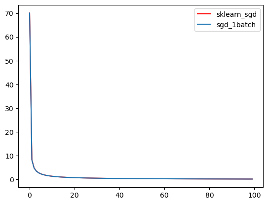

```python
cost_sklearn_cl = [log_loss(y_log, sigmoid(X_s_conc.dot(np.zeros((10,1)))), normalize=False)]
cost_batch_cl = []

classif_temp = SGDClassifier(loss="log_loss", max_iter=1, tol=None, penalty=None, learning_rate="constant",
                             eta0=0.1, warm_start=True) # Модель

classif_temp.fit(X_s,y_log.T[0], coef_init=np.zeros((9,1)),intercept_init=np.zeros((1))) # Обучение (1 итерация), beta_0=[0]_p
classif_temp_coef = np.append(classif_temp.coef_, classif_temp.intercept_).reshape(-1,1)
cost_sklearn_cl.append(log_loss(y_log, sigmoid(X_s_conc.dot(classif_temp_coef)), normalize=False)) # Добавляем значение функции риска

for i in range(classif.n_iter_):
    classif_temp.fit(X_s,y_log.T[0]) # Обучение (1 итерация)
    classif_temp_coef = np.append(classif_temp.coef_, classif_temp.intercept_).reshape(-1,1)
    cost_sklearn_cl.append(log_loss(y_log,sigmoid(X_s_conc.dot(classif_temp_coef)), normalize=False)) # Добавляем значения функции риска
    cost_batch_cl.append(log_loss(y_log, sigmoid(X_s_conc.dot(coef_batch_cl[101*i])), normalize=False))

plt.plot(cost_sklearn_cl[:-2],color="r", label="sklearn_sgd")
plt.plot(cost_batch_cl, label="sgd_1batch")
plt.legend()
```

SGD по подвыборке. 1000 итераций, подвыборка размера 10, шаг равен 0.1.

```python
coef_sgd_cl = Log_regr_SGD(X_s_conc, y_log, betta0=b0, alpha=0.1, eps=0, subsample_size=10, max_iter=1000)
print("Коэффициенты:\n",coef_sgd_cl[-1])
print("Sklearn-computed log loss:\n", log_loss(y_log, sigmoid(X_s_conc.dot(coef_sgd_cl[-1])), normalize=False))
print("Accuracy:\n", accuracy(np.round(sigmoid(X_s_conc.dot(coef_sgd_cl[-1]))), y_log))
```

```
Коэффициенты:
 [[ 0.53072187]
 [ 0.9352884 ]
 [-0.1099785 ]
 [ 2.38947259]
 [-3.43237861]
 [-5.28880861]
 [-0.4818995 ]
 [-0.83418448]
 [ 0.26430675]
 [ 1.02837328]]
Sklearn-computed log loss:
 0.20133512086269617
Accuracy:
 1.0
```

Adagrad.

```python
coef_adagrad_cl = Log_regr_Adagrad(X_s_conc, y_log, betta0=b0, alpha=0.1, eps=0, subsample_size=10, max_iter=1000)
print("Коэффициенты:\n",coef_adagrad_cl[-1])
print("Sklearn-computed log loss:\n", log_loss(y_log, sigmoid(X_s_conc.dot(coef_adagrad_cl[-1])), normalize=False))
print("Accuracy:\n", accuracy(np.round(sigmoid(X_s_conc.dot(coef_adagrad_cl[-1]))), y_log))
```

```
Коэффициенты:
 [[ 0.45648867]
 [ 0.63739816]
 [-0.44805412]
 [ 1.68566292]
 [-2.13790893]
 [-2.48521736]
 [-0.02738631]
 [-0.51608057]
 [ 0.1348412 ]
 [ 0.61961562]]
Sklearn-computed log loss:
 1.9705294077094149
Accuracy:
 1.0
```

RMSProp.

```python
coef_rms_cl = Log_regr_RMSProp(X_s_conc, y_log, betta0=b0, alpha=0.1, eps=0, subsample_size=10, max_iter=1000)
print("Коэффициенты:\n",coef_rms_cl[-1])
print("Sklearn-computed log loss:\n", log_loss(y_log, sigmoid(X_s_conc.dot(coef_rms_cl[-1])), normalize=False))
print("Accuracy:\n", accuracy(np.round(sigmoid(X_s_conc.dot(coef_rms_cl[-1]))), y_log))
```

```
Коэффициенты:
 [[ 0.76608845]
 [ 2.33336272]
 [-0.29547436]
 [ 4.79162263]
 [-6.60348787]
 [-9.66373492]
 [-1.40887297]
 [-1.94344997]
 [ 0.88417922]
 [ 1.94851772]]
Sklearn-computed log loss:
 0.00437130237365539
Accuracy:
 1.0
```

Графики функции риска по итерациям.

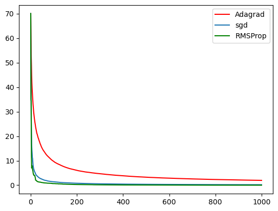

```python
cost_sgd_cl = []
cost_adagrad_cl = []
cost_rms_cl = []

for i in range(coef_sgd_cl.shape[0]):
    cost_sgd_cl.append(cost_log(sigmoid(X_s_conc.dot(coef_sgd_cl[i])),y_log)) # Добавляем значения функции риска
    cost_adagrad_cl.append(cost_log(sigmoid(X_s_conc.dot(coef_adagrad_cl[i])),y_log))
    cost_rms_cl.append(log_loss(y_log,sigmoid(X_s_conc.dot(coef_rms_cl[i])), normalize=False))

plt.plot(cost_adagrad_cl,color="r", label="Adagrad")
plt.plot(cost_sgd_cl, label="sgd")
plt.plot(cost_rms_cl,color="g", label="RMSProp")
plt.legend()
```